# Free Speech

Juanshu Wu

7/9/2021

#Load data and delete data who failed to consent or failed the attention check

```r
#Load data
library(tidyverse)
Dat <- read.csv("FreeSpeech.csv",TRUE)
#Only keep participants who consent to participate
Dat1 <- Dat %>% filter(Consent == "1")
#Delete the participants' data that fail the attention checks
Dat_attention_check_passed <- Dat1 %>% filter(Attention1 == 1)
```

#Categorize people into left and right slant

```r
Dat_filtered <- Dat_attention_check_passed %>% filter( Ideology != 9 | PoliticalParty!= 9)
Dat_filtered <- Dat_filtered %>% mutate(politicalslant = Ideology+PoliticalParty)
Dat_filtered <- Dat_filtered %>% filter(politicalslant != 0)
Dat_filtered$Political_Slant<-ifelse(Dat_filtered$politicalslant > 0,"right","left")
```

#Recode values

```r
Dat_filtered$X1.Prohibited = recode_factor(Dat_filtered$X1.Prohibited,"1"= "Yes","2" = "No","3" = "Not Sure")
Dat_filtered$X1.StudentAllow = recode_factor(Dat_filtered$X1.StudentAllow,"1"= "Yes","2" = "No","3" = "Not Sure")
Dat_filtered$X1.FacultyAllow = recode_factor(Dat_filtered$X1.FacultyAllow,"1"= "Yes","2" = "No","3" = "Not Sure")
Dat_filtered$X1.LibraryAllow= recode_factor(Dat_filtered$X1.LibraryAllow,"1"= "Yes","2" = "No","3" = "Not Sure")
Dat_filtered$X2.Prohibited = recode_factor(Dat_filtered$X2.Prohibited,"1"= "Yes","2" = "No","3" = "Not Sure")
Dat_filtered$X2.StudentAllow = recode_factor(Dat_filtered$X2.StudentAllow,"1"= "Yes","2" = "No","3" = "Not Sure")
Dat_filtered$X2.FacultyAllow = recode_factor(Dat_filtered$X2.FacultyAllow,"1"= "Yes","2" = "No","3" = "Not Sure")
Dat_filtered$X2.LibraryAllow= recode_factor(Dat_filtered$X2.LibraryAllow,"1"= "Yes","2" = "No","3" = "Not Sure")
```

#StudentAllow Proportion for most harmful belief(Political Slant)

```r
#Chi_Square
chisq.test(Dat_filtered$Political_Slant,Dat_filtered$X1.StudentAllow)
```

```
##
##  Pearson's Chi-squared test
##
## data:  Dat_filtered$Political_Slant and Dat_filtered$X1.StudentAllow
## X-squared = 8.176, df = 2, p-value = 0.01677
```

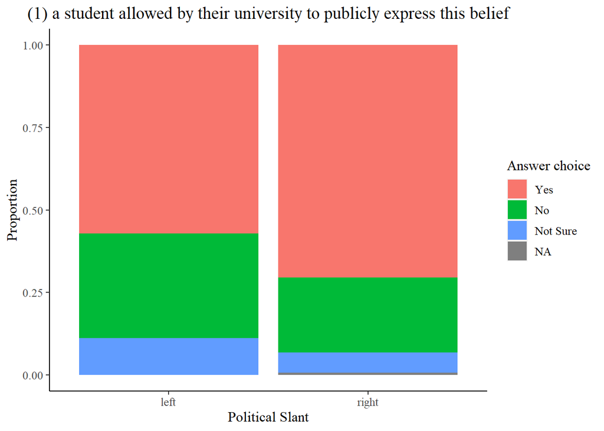

```r
#Stacked
ggplot(Dat_filtered, aes(Political_Slant, fill=X1.StudentAllow)) +
  geom_bar(position="fill")+theme (plot.title = element_text(hjust = 0.5),text = element_text(family = "serif", size = 12),panel.grid.major = element_blank(), panel.grid.minor = element_blank(),panel.background = element_blank(), axis.line = element_line(colour = "black"))+
ggtitle(" (1) a student allowed by their university to publicly express this belief ")+labs(y = "Proportion", x = "Political Slant",fill = "Answer choice")
```

```r
# bar dodged
#ggplot(Dat_filtered, aes(Political_Slant, fill=X1.StudentAllow)) +
  #geom_bar(position="dodge")
```

#Prohibited proportion for most harmful belief(Political Slant)

```r
#Chi_Square
chisq.test(Dat_filtered$Political_Slant,Dat_filtered$X1.Prohibited)
```

```
##
##  Pearson's Chi-squared test
##
## data:  Dat_filtered$Political_Slant and Dat_filtered$X1.Prohibited
## X-squared = 2.5958, df = 2, p-value = 0.2731
```

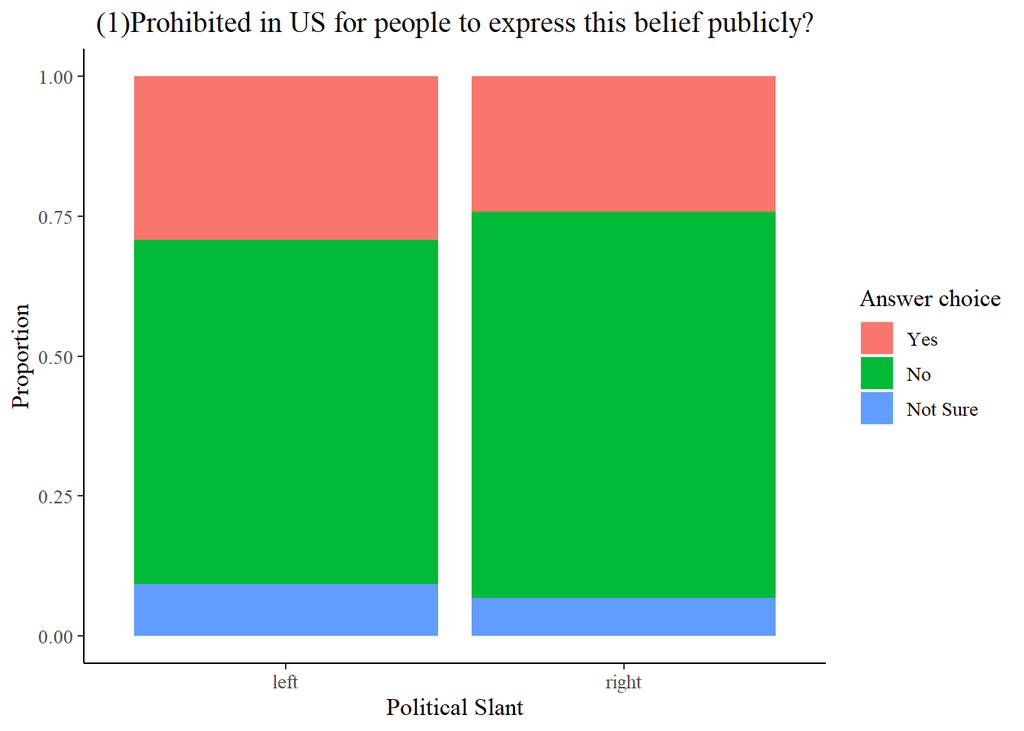

```r
# stacked
ggplot(Dat_filtered, aes(Political_Slant, fill=X1.Prohibited)) +
  geom_bar(position="fill")+theme(plot.title = element_text(hjust = 0.5),text = element_text(family = "serif",size = 12),panel.grid.major = element_blank(), panel.grid.minor =element_blank(),panel.background = element_blank(), axis.line = element_line(colour = "black"))+
ggtitle("(1)Prohibited in US for people to express this belief publicly?")+labs(y = "Proportion", x = "Political Slant",fill = "Answer choice")
```

```r
# bar dodged
#ggplot(Dat_filtered, aes(Political_Slant, fill=X1.StudentAllow)) +
  #geom_bar(position="dodge")
```

#FacultyAllow proportion for most harmful belief(Political Slant)

```r
chisq.test(Dat_filtered$Political_Slant,Dat_filtered$X1.FacultyAllow)
```

```
##
##  Pearson's Chi-squared test
##
## data:  Dat_filtered$Political_Slant and Dat_filtered$X1.FacultyAllow
## X-squared = 10.397, df = 2, p-value = 0.005525
```

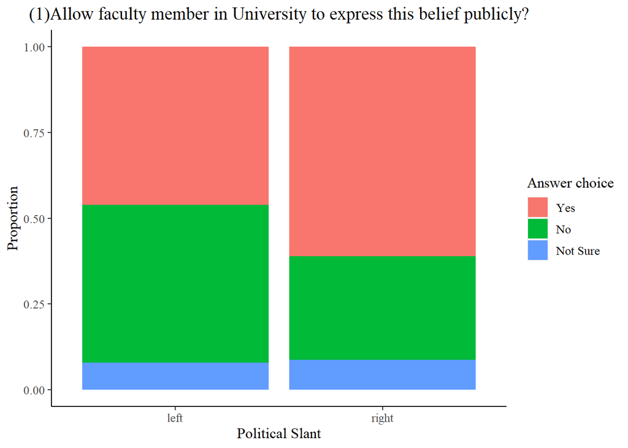

```r
# stacked
ggplot(Dat_filtered, aes(Political_Slant, fill=X1.FacultyAllow)) +
  geom_bar(position="fill")+theme(plot.title = element_text(hjust = 0.5),text = element_text(family = "serif",size = 12),panel.grid.major = element_blank(), panel.grid.minor =element_blank(),panel.background = element_blank(), axis.line = element_line(colour = "black"))+
ggtitle("(1)Allow faculty member in University to express this belief publicly?")+labs(y = "Proportion", x = "Political Slant",fill = "Answer choice")
```

```r
# bar dodged
#ggplot(Dat_filtered, aes(Political_Slant, fill=X1.StudentAllow)) +
  #geom_bar(position="dodge")
```

#Library allow porpotion for most harmful belief(Political Slant)

```r
chisq.test(Dat_filtered$Political_Slant,Dat_filtered$X1.LibraryAllow)
```

```
##
##  Pearson's Chi-squared test
##
## data:  Dat_filtered$Political_Slant and Dat_filtered$X1.LibraryAllow
## X-squared = 7.1993, df = 2, p-value = 0.02733
```

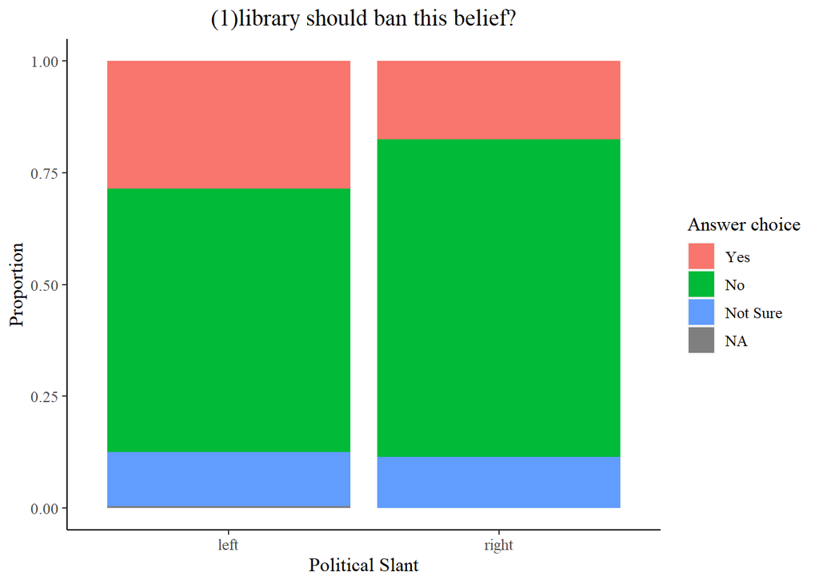

```r
# stacked
ggplot(Dat_filtered, aes(Political_Slant, fill=X1.LibraryAllow)) +
  geom_bar(position="fill")+theme(plot.title = element_text(hjust = 0.5),text = element_text(family = "serif",size = 12),panel.grid.major = element_blank(), panel.grid.minor =element_blank(),panel.background = element_blank(), axis.line = element_line(colour = "black"))+
ggtitle("(1)library should ban this belief?")+labs(y = "Proportion", x = "Political Slant",fill = "Answer choice")
```

```r
# bar dodged
#ggplot(Dat_filtered, aes(Political_Slant, fill=X1.StudentAllow)) +
  #geom_bar(position="dodge")
```

#Student Allow proportion for second most harmful belief(Political Slant)

```r
chisq.test(Dat_filtered$Political_Slant,Dat_filtered$X2.StudentAllow)
```

```
##
##  Pearson's Chi-squared test
##
## data:  Dat_filtered$Political_Slant and Dat_filtered$X2.StudentAllow
## X-squared = 2.5023, df = 2, p-value = 0.2862
```

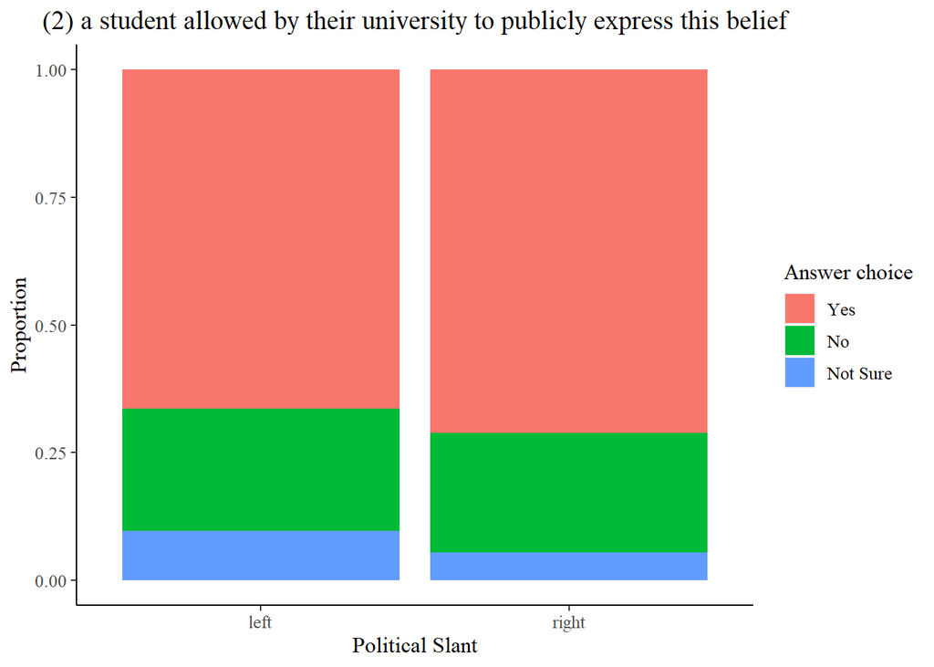

```r
# stacked
ggplot(Dat_filtered, aes(Political_Slant, fill=X2.StudentAllow)) +
  geom_bar(position="fill")+theme (plot.title = element_text(hjust = 0.5),text = element_text(family = "serif", size = 12),panel.grid.major = element_blank(), panel.grid.minor = element_blank(),panel.background = element_blank(), axis.line = element_line(colour = "black"))+ggtitle("(2) a student allowed by their university to publicly express this belief")+labs(y ="Proportion", x = "Political Slant",fill = "Answer choice")
```

```r
# bar dodged
#ggplot(Dat_filtered, aes(Political_Slant, fill=X1.StudentAllow)) +
  #geom_bar(position="dodge")
```

#Prohibited proprotion for second most harmful belief(Political Slant)

```r
chisq.test(Dat_filtered$Political_Slant,Dat_filtered$X2.Prohibited)
```

```
##
##  Pearson's Chi-squared test
##
## data:  Dat_filtered$Political_Slant and Dat_filtered$X2.Prohibited
## X-squared = 1.5785, df = 2, p-value = 0.4542
```

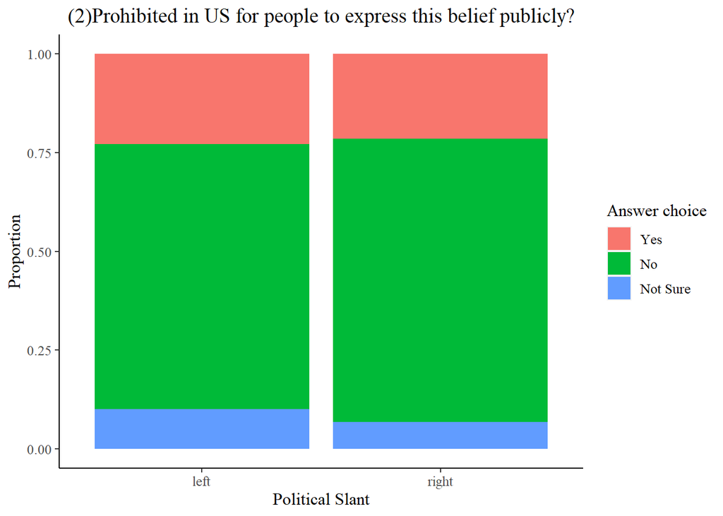

```r
# stacked
ggplot(Dat_filtered, aes(Political_Slant, fill=X2.Prohibited)) +
  geom_bar(position="fill")+theme(plot.title = element_text(hjust = 0.5),text = element_text(family = "serif",size = 12),panel.grid.major = element_blank(), panel.grid.minor =element_blank(),panel.background = element_blank(), axis.line = element_line(colour = "black"))+
ggtitle("(2)Prohibited in US for people to express this belief publicly?")+labs(y = "Proportion", x = "Political Slant",fill = "Answer choice")
```

```r
# bar dodged
#ggplot(Dat_filtered, aes(Political_Slant, fill=X1.StudentAllow)) +
  #geom_bar(position="dodge")
```

#FacultyAllow proportion for second most harmful belief(Political Slant)

```r
chisq.test(Dat_filtered$Political_Slant,Dat_filtered$X2.FacultyAllow)
```

```
##
##  Pearson's Chi-squared test
##
## data:  Dat_filtered$Political_Slant and Dat_filtered$X2.FacultyAllow
## X-squared = 2.8268, df = 2, p-value = 0.2433
```

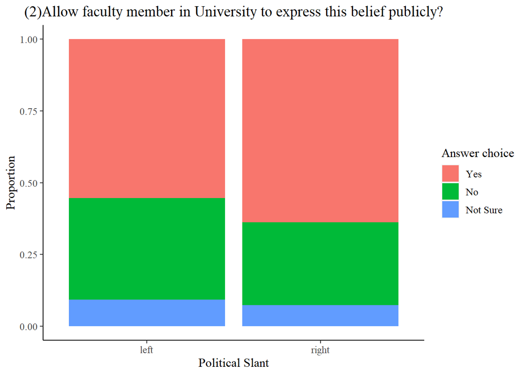

```r
# stacked
ggplot(Dat_filtered, aes(Political_Slant, fill=X2.FacultyAllow)) +
  geom_bar(position="fill")+
  theme(plot.title = element_text(hjust = 0.5),text = element_text(family = "serif",size = 12),panel.grid.major = element_blank(), panel.grid.minor =element_blank(),panel.background = element_blank(), axis.line = element_line(colour = "black"))+
ggtitle("(2)Allow faculty member in University to express this belief publicly?")+labs(y = "Proportion", x = "Political Slant",fill = "Answer choice")
```

```r
# bar dodged
#ggplot(Dat_filtered, aes(Political_Slant, fill=X1.StudentAllow)) +
  #geom_bar(position="dodge")
```

#LibraryAllow proportion for second most harmful belief(Political Slant)

```r
chisq.test(Dat_filtered$Political_Slant,Dat_filtered$X2.LibraryAllow)
```

```
##
##  Pearson's Chi-squared test
##
## data:  Dat_filtered$Political_Slant and Dat_filtered$X2.LibraryAllow
## X-squared = 6.9365, df = 2, p-value = 0.03117
```

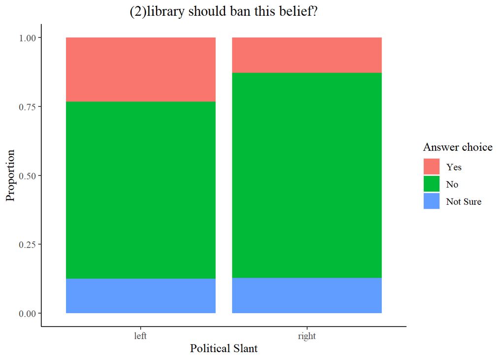

```r
# stacked
ggplot(Dat_filtered, aes(Political_Slant, fill=X2.LibraryAllow)) +
  geom_bar(position="fill")+theme(plot.title = element_text(hjust = 0.5),text = element_text(family = "serif",size = 12),panel.grid.major = element_blank(), panel.grid.minor =element_blank(),panel.background = element_blank(), axis.line = element_line(colour = "black"))+
ggtitle("(2)library should ban this belief?")+labs(y = "Proportion", x = "Political Slant",fill = "Answer choice")
```

```r
# bar dodged
#ggplot(Dat_filtered, aes(Political_Slant, fill=X1.StudentAllow)) +
  #geom_bar(position="dodge")
```

#recode Gender

```r
#Recode Gender numeric value into gender category
Dat_filtered$Gender= recode_factor(Dat_filtered$Gender,"1"= "Male","2" = "Female")
```

#StudentAllow Proportion for most harmful belief(Gender)

```r
#Chi_Square
chisq.test(Dat_filtered$Gender,Dat_filtered$X1.StudentAllow)
```

```
##
##  Pearson's Chi-squared test
##
## data:  Dat_filtered$Gender and Dat_filtered$X1.StudentAllow
## X-squared = 14.33, df = 2, p-value = 0.0007733
```

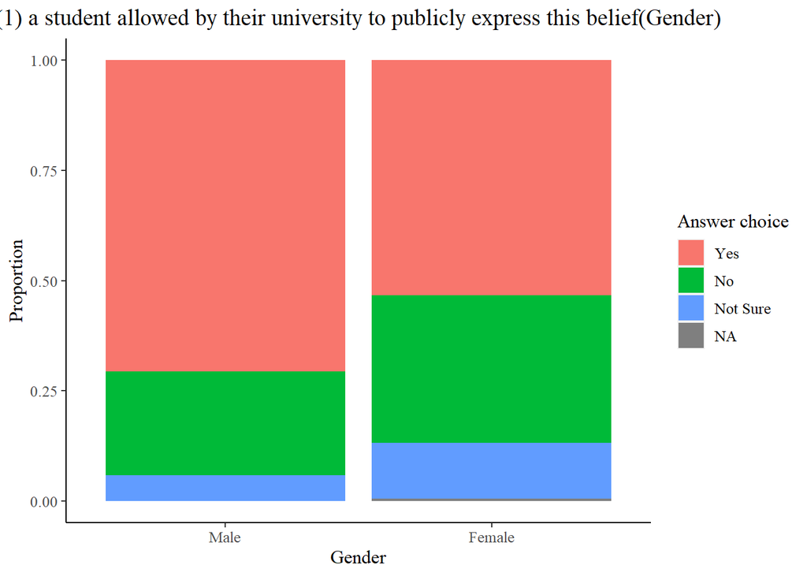

```r
#Stacked
ggplot(Dat_filtered, aes(Gender, fill=X1.StudentAllow)) +
  geom_bar(position="fill")+theme (plot.title = element_text(hjust = 0.5),text = element_text(family = "serif", size = 12),panel.grid.major = element_blank(), panel.grid.minor = element_blank(),panel.background = element_blank(), axis.line = element_line(colour = "black"))+
ggtitle("(1) a student allowed by their university to publicly express this belief(Gender)")+labs(y = "Proportion", x = "Gender",fill = "Answer choice")
```

```r
# bar dodged
#ggplot(Dat_filtered, aes(Political_Slant, fill=X1.StudentAllow)) +
  #geom_bar(position="dodge")
```

#Prohibited proportion for most harmful belief(Gender)

```r
#Chi_Square
chisq.test(Dat_filtered$Gender,Dat_filtered$X1.Prohibited)
```

```
##
##  Pearson's Chi-squared test
##
## data:  Dat_filtered$Gender and Dat_filtered$X1.Prohibited
## X-squared = 2.4475, df = 2, p-value = 0.2941
```

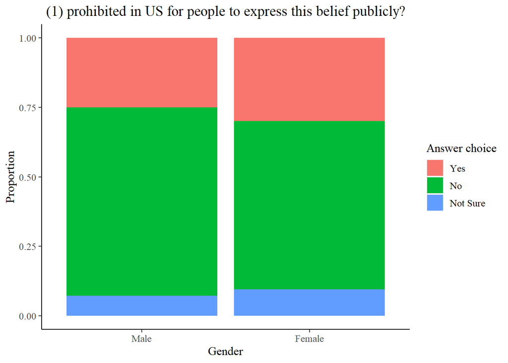

```r
# stacked
ggplot(Dat_filtered, aes(Gender, fill=X1.Prohibited)) +
  geom_bar(position="fill")+theme(plot.title = element_text(hjust = 0.5),text = element_text(family = "serif",size = 12),panel.grid.major = element_blank(), panel.grid.minor =element_blank(),panel.background = element_blank(), axis.line = element_line(colour = "black"))+
ggtitle("(1) prohibited in US for people to express this belief publicly?")+labs(y = "Proportion", x = "Gender",fill = "Answer choice")
```

```r
# bar dodged
#ggplot(Dat_filtered, aes(Political_Slant, fill=X1.StudentAllow)) +
  #geom_bar(position="dodge")
```

#FacultyAllow proportion for most harmful belief(Gender)

```r
chisq.test(Dat_filtered$Gender,Dat_filtered$X1.FacultyAllow)
```

```
##
##  Pearson's Chi-squared test
##
## data:  Dat_filtered$Gender and Dat_filtered$X1.FacultyAllow
## X-squared = 5.7945, df = 2, p-value = 0.05518
```

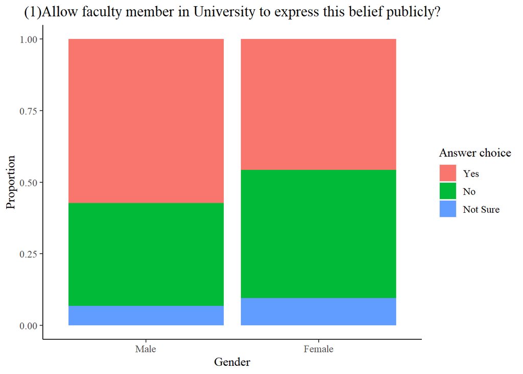

```r
# stacked
ggplot(Dat_filtered, aes(Gender, fill=X1.FacultyAllow)) +
  geom_bar(position="fill")+theme(plot.title = element_text(hjust = 0.5),text = element_text(family = "serif",size = 12),panel.grid.major = element_blank(), panel.grid.minor =element_blank(),panel.background = element_blank(), axis.line = element_line(colour = "black"))+
ggtitle("(1)Allow faculty member in University to express this belief publicly?")+labs(y = "Proportion", x = "Gender",fill = "Answer choice")
```

```r
# bar dodged
#ggplot(Dat_filtered, aes(Political_Slant, fill=X1.StudentAllow)) +
  #geom_bar(position="dodge")
```

#Library allow porpotion for most harmful belief(Gender)

```r
chisq.test(Dat_filtered$Gender,Dat_filtered$X1.LibraryAllow)
```

```
##
##  Pearson's Chi-squared test
##
## data:  Dat_filtered$Gender and Dat_filtered$X1.LibraryAllow
## X-squared = 1.9493, df = 2, p-value = 0.3773
```

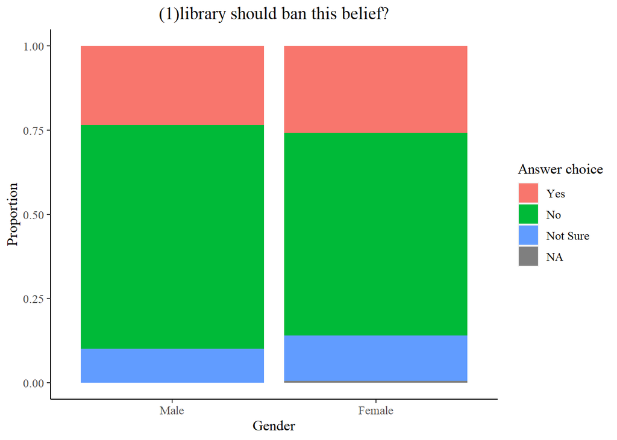

```r
# stacked
ggplot(Dat_filtered, aes(Gender, fill=X1.LibraryAllow)) +
  geom_bar(position="fill")+theme(plot.title = element_text(hjust = 0.5),text = element_text(family = "serif",size = 12),panel.grid.major = element_blank(), panel.grid.minor =element_blank(),panel.background = element_blank(), axis.line = element_line(colour = "black"))+
ggtitle("(1)library should ban this belief?")+labs(y = "Proportion", x = "Gender",fill = "Answer choice")
```

```r
# bar dodged
#ggplot(Dat_filtered, aes(Political_Slant, fill=X1.StudentAllow)) +
  #geom_bar(position="dodge")
```

#Student Allow proportion for second most harmful belief(Gender)

```r
chisq.test(Dat_filtered$Gender,Dat_filtered$X2.StudentAllow)
```

```
##
##  Pearson's Chi-squared test
##
## data:  Dat_filtered$Gender and Dat_filtered$X2.StudentAllow
## X-squared = 5.7628, df = 2, p-value = 0.05606
```

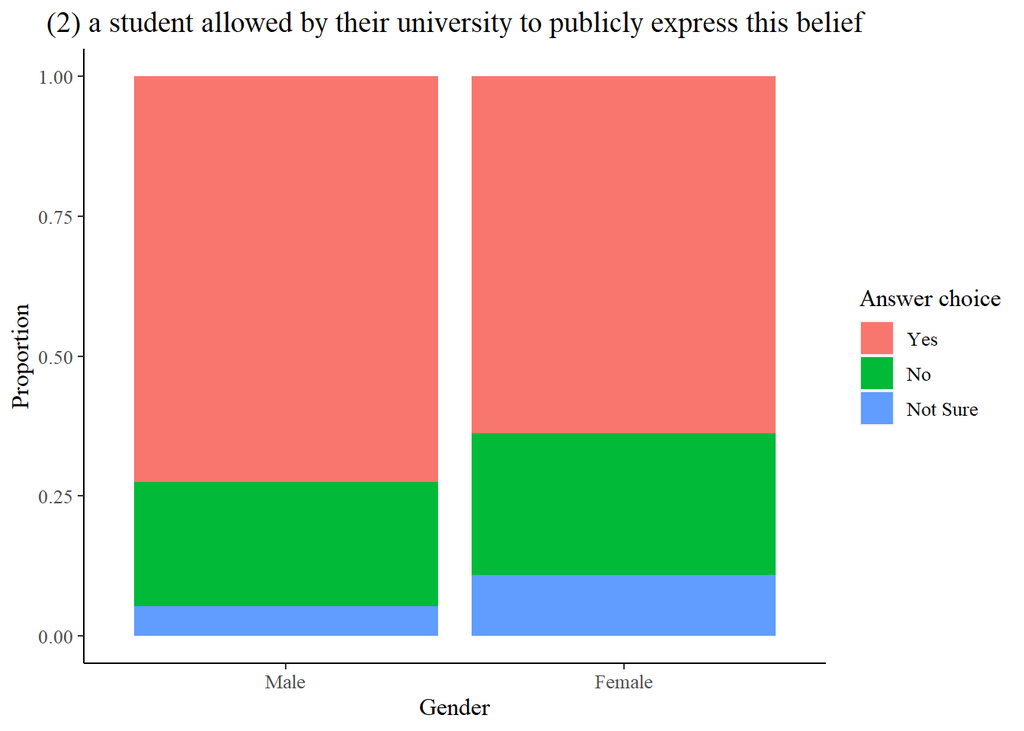

```r
# stacked
ggplot(Dat_filtered, aes(Gender, fill=X2.StudentAllow)) +
  geom_bar(position="fill")+theme (plot.title = element_text(hjust = 0.5),text = element_text(family = "serif", size = 12),panel.grid.major = element_blank(), panel.grid.minor = element_blank(),panel.background = element_blank(), axis.line = element_line(colour = "black"))+ggtitle("(2) a student allowed by their university to publicly express this belief")+labs(y ="Proportion", x = "Gender",fill = "Answer choice")
```

```r
# bar dodged
#ggplot(Dat_filtered, aes(Political_Slant, fill=X1.StudentAllow)) +
  #geom_bar(position="dodge")
```

#Prohibited proprotion for second most harmful belief(Gender)

```r
chisq.test(Dat_filtered$Gender,Dat_filtered$X2.Prohibited)
```

```
##
##  Pearson's Chi-squared test
##
## data:  Dat_filtered$Gender and Dat_filtered$X2.Prohibited
## X-squared = 1.4617, df = 2, p-value = 0.4815
```

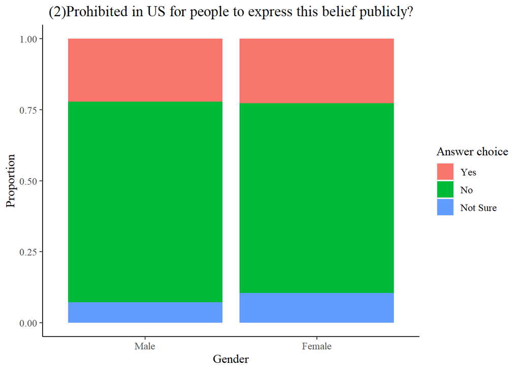

```r
# stacked
ggplot(Dat_filtered, aes(Gender, fill=X2.Prohibited)) +
  geom_bar(position="fill")+theme(plot.title = element_text(hjust = 0.5),text = element_text(family = "serif",size = 12),panel.grid.major = element_blank(), panel.grid.minor =element_blank(),panel.background = element_blank(), axis.line = element_line(colour = "black"))+
ggtitle("(2)Prohibited in US for people to express this belief publicly?")+labs(y = "Proportion", x = "Gender",fill = "Answer choice")
```

```r
# bar dodged
#ggplot(Dat_filtered, aes(Political_Slant, fill=X1.StudentAllow)) +
  #geom_bar(position="dodge")
```

#FacultyAllow proportion for second most harmful belief(Gender)

```r
chisq.test(Dat_filtered$Gender,Dat_filtered$X2.FacultyAllow)
```

```
##
##  Pearson's Chi-squared test
##
## data:  Dat_filtered$Gender and Dat_filtered$X2.FacultyAllow
## X-squared = 1.2948, df = 2, p-value = 0.5234
```

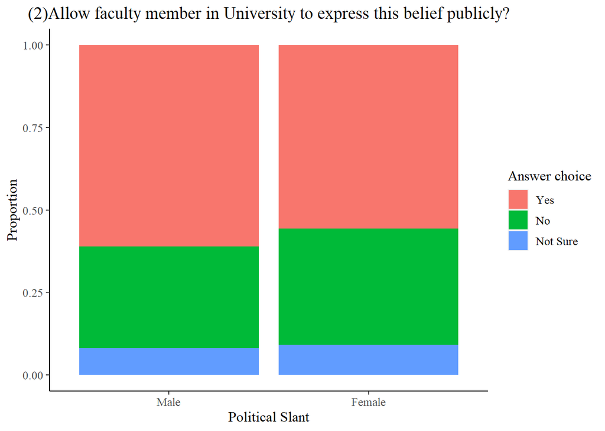

```r
# stacked
ggplot(Dat_filtered, aes(Gender, fill=X2.FacultyAllow)) +
  geom_bar(position="fill")+
  theme(plot.title = element_text(hjust = 0.5),text = element_text(family = "serif",size = 12),panel.grid.major = element_blank(), panel.grid.minor =element_blank(),panel.background = element_blank(), axis.line = element_line(colour = "black"))+
ggtitle("(2)Allow faculty member in University to express this belief publicly?")+labs(y = "Proportion", x = "Political Slant",fill = "Answer choice")
```

```r
# bar dodged
#ggplot(Dat_filtered, aes(Political_Slant, fill=X1.StudentAllow)) +
  #geom_bar(position="dodge")
```

#LibraryAllow proportion for second most harmful belief(Gender)

```r
chisq.test(Dat_filtered$Gender,Dat_filtered$X2.LibraryAllow)
```

```
##
##  Pearson's Chi-squared test
##
## data:  Dat_filtered$Gender and Dat_filtered$X2.LibraryAllow
## X-squared = 2.3237, df = 2, p-value = 0.3129
```

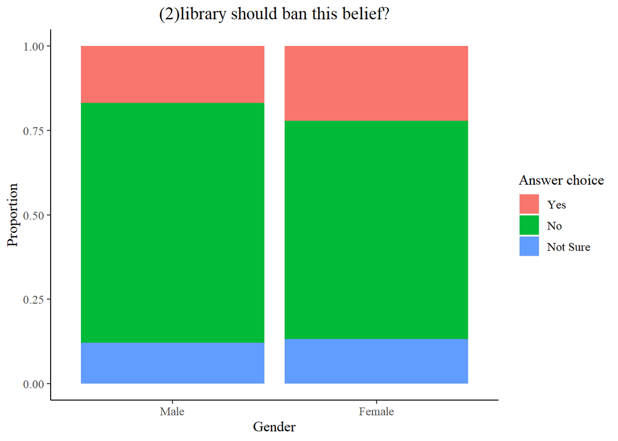

```r
# stacked
ggplot(Dat_filtered, aes(Gender, fill=X2.LibraryAllow)) +
  geom_bar(position="fill")+theme(plot.title = element_text(hjust = 0.5),text = element_text(family = "serif",size = 12),panel.grid.major = element_blank(), panel.grid.minor =element_blank(),panel.background = element_blank(), axis.line = element_line(colour = "black"))+
ggtitle("(2)library should ban this belief?")+labs(y = "Proportion", x = "Gender",fill = "Answer choice")
```

```r
# bar dodged
#ggplot(Dat_filtered, aes(Political_Slant, fill=X1.StudentAllow)) +
  #geom_bar(position="dodge")
```